# Non-Profits of the Arts in Santa Barbara

John Ferrone

2 May 2023

## Introduction

The nonprofit community in Santa Barbara is made up of thousands of individual organizations which range from housing to international aid to the arts. In particular, the nonprofit organizations which focus on the arts, music, and entertainment are some of the biggest in the city. We investigated the financials of thirteen of these organizations in order to illuminate some trends in this scene. Data was collected for the tax years ending in 2019 and 2020, using ProPublica’s Nonprofit Explorer which pulled directly from IRS tax returns. Our goal was to provide the community with more information on these nonprofit organizations and to foster well-informed contributions.

## Contributions

Nonprofits in the United States are a massive industry, with large asset holdings and revenue streams. The same can be said for the non-profit scene in Santa Barbara, where contributions for the thirteen organizations featured in this report total $36,969,521 during the surveyed years. **Figure 1** displays the total contributions which were reported by each organization in the tax year ending in late 2019 or 2020. The contributions to these nonprofits vary heavily depending on the particular organization, with the total reported number of contributions ranging from just under $500,000 to Casa del Herrero to over $7,000,000 to the Santa Barbara Art Museum. Contributions represented one of the two main ways the thirteen organizations fundraised, with the other being Program Service Revenues.

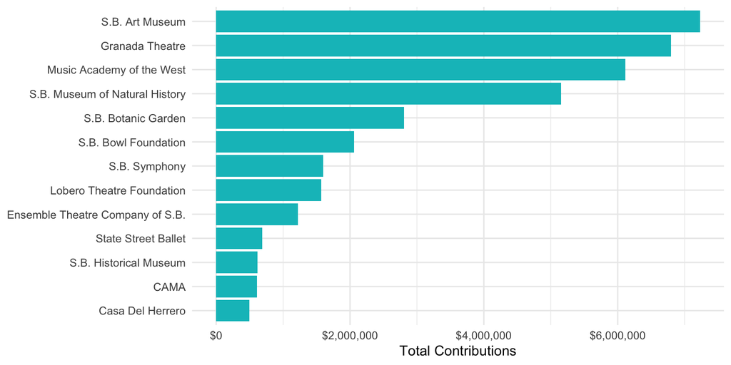

> **Figure 1**: Total Contributions

## Revenue, Expenses, and Assets

The Program Service Revenue, which included ticket sales, theatre rentals, and other program-related sources of income, does not make up more than half of revenue for any of the thirteen organizations. On average the Program Service Revenue only covered 22.4% of the operating costs for the selected organizations. For comparison, donor contributions accounted for 63.8% of organization operating costs. Actual individual operating cost coverage varied by organization, however, on the whole this figure underscored how community contributions made up a majority of operating cost coverage, and almost three times as much as total Program Service Revenue.

Upon further inspection of organizations revenue streams, only four nonprofits generated a surplus or more revenue than they had expenses. **Figure 2** displays the total revenue and expenses of each organization. The margins are close, but this is not unusual for nonprofit organizations. The generated revenue was used in such a way that it allowed for growth once it had exceeded the built-in costs.

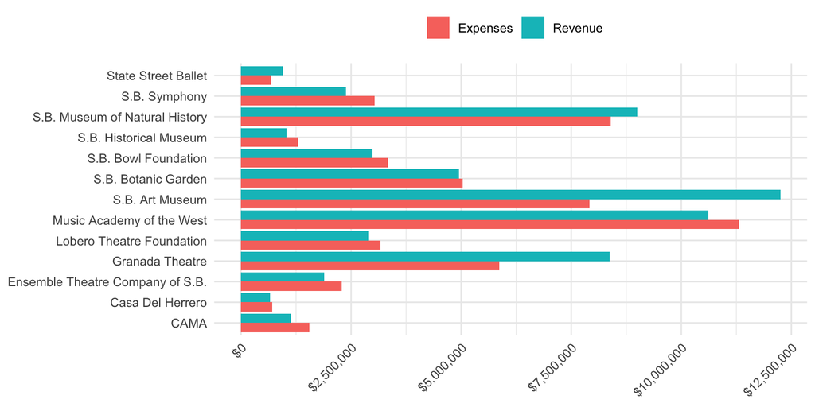

> **Figure 2**: Total Revenue vs. Total Expenses

## The Organizational Workforce

| Organization | Employees | Volunteers |
| --- | --- | --- |
| CAMA | 4 | 60 |
| Casa Del Herrero | 5 | 88 |
| Ensemble Theatre Company of S.B. | 86 | 125 |
| Granada Theatre | 181 | 120 |
| Lobero Theatre Foundation | 89 | 50 |
| Music Academy of the West | 78 | 225 |
| S.B. Art Museum | 106 | 130 |
| S.B. Botanic Garden | 75 | 225 |
| S.B. Bowl Foundation | 14 | 35 |
| S.B. Historical Museum | 20 | 38 |
| S.B. Museum of Natural History | 207 | 906 |
| S.B. Symphony | 200 | 20 |
| State Street Ballet | 0 | 10 |

> **Figure 3**: Table of Organizations and their Employees and Volunteer Count

The arts nonprofit community in Santa Barbara provided many employment and volunteer opportunities. In total 1,065 individuals were employed by these organizations. Volunteer numbers reported to the IRS are an estimate, but 2,032 individuals were reported as having volunteered for these thirteen organizations. Volunteers for the Santa Barbara Museum of Natural History comprised the single largest volunteer staff at 906 individuals. Volunteers make up two-thirds of the workforce at the selected organizations.

While only one-third of the workforce comprised employed individuals, the salaries of these individuals accounted for one of the biggest expenses to the nonprofit organizations. When taken as a percentage of the revenue about 44% of each organizations' revenue is immediately spent on salaries, benefits, and compensation which is a huge amount and may emphasize the need for more volunteers within the community.

In particular, the directors of these organizations took up a notable portion of the salaries. On average, 19.75% of the funds which went to salaried individuals went entirely to the director of the organization. This value does not necessarily mean much as the compensation of the director is different in each organization. Two organizations illustrated this well, The Santa Barbara Symphony and the State Street Ballet. In the first case, the director does not receive a salary and thus contributes to 0% of the reported cost. In the second case, the director is the only paid individual in the organization and thus receives 100% of the expenses related to salary. Furthermore, the highest paid director of these organizations is that of the Music Academy of the West at $452,000, more than double the next highest salary.